# Data Analysis on the Auto, College and Boston Datsets

### 2a.

The following variables are quantitative: mpg, cylinders, displacement, horsepower, weight and acceleration. The following variables are qualitative: year, origin and name.

```r
auto <- read.csv("/Users/admin/Downloads/Auto.csv")
auto <- na.omit(auto)
glimpse(auto)
```

```
## Rows: 371
## Columns: 9
## $ mpg          <dbl> 18, 15, 18, 16, 17, 15, 14, 14, 14, 15, 15, 14, 15, 14, 2…
## $ cylinders    <int> 8, 8, 8, 8, 8, 8, 8, 8, 8, 8, 8, 8, 8, 8, 4, 6, 6, 6, 4, …
## $ displacement <dbl> 307, 350, 318, 304, 302, 429, 454, 440, 455, 390, 383, 34…
## $ horsepower   <int> 130, 165, 150, 150, 140, 198, 220, 215, 225, 190, 170, 16…
## $ weight       <int> 3504, 3693, 3436, 3433, 3449, 4341, 4354, 4312, 4425, 385…
## $ acceleration <dbl> 12.0, 11.5, 11.0, 12.0, 10.5, 10.0, 9.0, 8.5, 10.0, 8.5, …
## $ year         <int> 70, 70, 70, 70, 70, 70, 70, 70, 70, 70, 70, 70, 70, 70, 7…
## $ origin       <int> 1, 1, 1, 1, 1, 1, 1, 1, 1, 1, 1, 1, 1, 1, 3, 1, 1, 1, 3, …
## $ name         <chr> "chevrolet chevelle malibu", "buick skylark 320", "plymou…
```

### 2b.Ranges for each quantitative predictor

Converting the qualitative variables to factors.

```r
auto$year <- as.factor(auto$year)
auto$origin <- as.factor(auto$origin)
auto$name <- as.factor(auto$name)
```

Converting the int and double variables to numeric

```r
auto$mpg <- as.numeric(auto$mpg)
auto$cylinders <- as.numeric(auto$cylinders)
auto$displacement <- as.numeric(auto$displacement)
auto$horsepower <- as.numeric(auto$horsepower)
auto$weight <- as.numeric(auto$weight)
auto$acceleration <- as.numeric(auto$acceleration)
```

Finding the ranges for each quantitative predictor

```r
range(auto$mpg)
```

```
## [1]  9.0 46.6
```

```r
range(auto$cylinders)
```

```
## [1] 3 8
```

```r
range(auto$displacement)
```

```
## [1]  68 455
```

```r
range(auto$horsepower)
```

```
## [1]  46 230
```

```r
range(auto$weight)
```

```
## [1] 1613 5140
```

```r
range(auto$acceleration)
```

```
## [1]  8.0 24.8
```

### 2c. Mean and standard deviation for each quantitative predictor

```r
auto %>%
  select(mpg, cylinders, displacement, horsepower, weight, acceleration) %>%
  skim()
```

Data summary

| Name | Piped data |
| --- | --- |
| Number of rows | 371 |
| Number of columns | 6 |
| _______________________ |  |
| Column type frequency: |  |
| numeric | 6 |
| ________________________ |  |
| Group variables | None |

**Variable type: numeric**

| skim_variable | n_missing | complete_rate | mean | sd | p0 | p25 | p50 | p75 | p100 | hist |
| --- | --- | --- | --- | --- | --- | --- | --- | --- | --- | --- |
| mpg | 0 | 1 | 23.69 | 7.87 | 9 | 17.5 | 23.0 | 29.5 | 46.6 | ▆▇▆▃▁ |
| cylinders | 0 | 1 | 5.44 | 1.71 | 3 | 4.0 | 4.0 | 8.0 | 8.0 | ▇▁▃▁▃ |
| displacement | 0 | 1 | 192.08 | 105.25 | 68 | 99.5 | 144.0 | 284.5 | 455.0 | ▇▂▂▃▁ |
| horsepower | 0 | 1 | 104.39 | 39.00 | 46 | 75.0 | 92.0 | 127.0 | 230.0 | ▆▇▃▂▁ |
| weight | 0 | 1 | 2954.67 | 847.86 | 1613 | 2219.5 | 2755.0 | 3589.5 | 5140.0 | ▇▇▅▅▂ |
| acceleration | 0 | 1 | 15.50 | 2.76 | 8 | 13.7 | 15.5 | 17.0 | 24.8 | ▁▆▇▂▁ |

mpg: mean = 23.7, sd = 7.87 cylinders: mean = 5.44, sd = 1.71 displacement: mean = 192, sd= 105 horsepower: mean = 104, sd = 39 weight: mean = 2955, sd = 848 acceleration: mean = 15.5, sd = 2.76

```r
removed <- 5:15
auto_less10 <- auto[-removed, ]

range(auto_less10$mpg)
```

```
## [1]  9.0 46.6
```

```r
range(auto_less10$cylinders)
```

```
## [1] 3 8
```

```r
range(auto_less10$displacement)
```

```
## [1]  68 455
```

```r
range(auto_less10$horsepower)
```

```
## [1]  46 230
```

```r
range(auto_less10$weight)
```

```
## [1] 1613 5140
```

```r
range(auto_less10$acceleration)
```

```
## [1]  9.5 24.8
```

### 2e.Predicting gas mileage on the basis of other variables

Correlation

The correlation between cylinders and mpg is a strong correlation at -0.776896.

```r
cor(auto$cylinders, auto$mpg)
```

```
## [1] -0.776896
```

Setting the seed for reproducibility

```r
set.seed(1)
```

Sampling the dataset

```r
row.number <- sample(1:nrow(auto), 0.8 * nrow(auto))
```

Splitting the dataset into train and test sets

```r
train <- auto[row.number, ]
test <- auto[-row.number, ]

dim_train <- dim(train)
dim_test <- dim(test)
dim_train
```

```
## [1] 296   9
```

```r
dim_test
```

```
## [1] 75  9
```

Fit the linear model

```r
auto_model <- lm(mpg ~ cylinders, data = train)
summary(auto_model)
```

```
##
## Call:
## lm(formula = mpg ~ cylinders, data = train)
##
## Residuals:
##     Min      1Q  Median      3Q     Max
## -14.671  -3.098  -0.726   2.944  17.552
##
## Coefficients:
##             Estimate Std. Error t value Pr(>|t|)
## (Intercept)  43.5379     0.9812   44.37   <2e-16 ***
## cylinders    -3.6224     0.1725  -20.99   <2e-16 ***
## ---
## Signif. codes:  0 '***' 0.001 '**' 0.01 '*' 0.05 '.' 0.1 ' ' 1
##
## Residual standard error: 5.09 on 294 degrees of freedom
## Multiple R-squared:  0.5999, Adjusted R-squared:  0.5985
## F-statistic: 440.8 on 1 and 294 DF,  p-value: < 2.2e-16
```

Make predictions on the test data

```r
predictions <- predict(auto_model, newdata = test)
```

Calculating Mean Squared Error and R-squared

```r
mse <- mean((test$mpg - predictions)^2)
mse
```

```
## [1] 19.64836
```

```r
rss <- sum((test$mpg - predictions)^2)
tss <- sum((test$mpg - mean(test$mpg)) ^2)
rsquared <- 1 - (rss/tss)
rsquared
```

```
## [1] 0.6128595
```

The rsquared value is a little over halfway close to 1, so it isn’t the strongest fit.

Scatterplot of cylinders and mpg

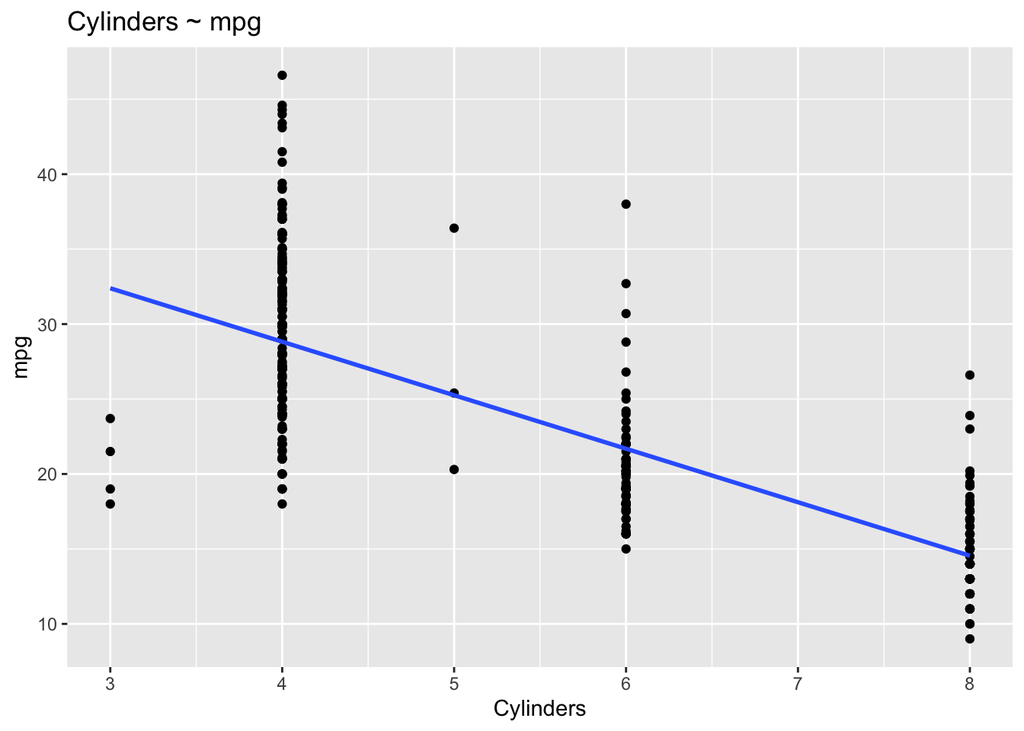

```r
ggplot(auto, mapping = aes(x = cylinders, y = mpg)) +
  geom_point() +
  labs(x = "Cylinders", y = "mpg", title = "Cylinders ~ mpg") +
  geom_smooth(method = "lm", se = FALSE)
```

Correlation

The correlation between weight and mpg is a strong correlation at -0.8324161.

```r
cor(auto$weight, auto$mpg)
```

```
## [1] -0.8324161
```

Scatterplot of weight and mpg

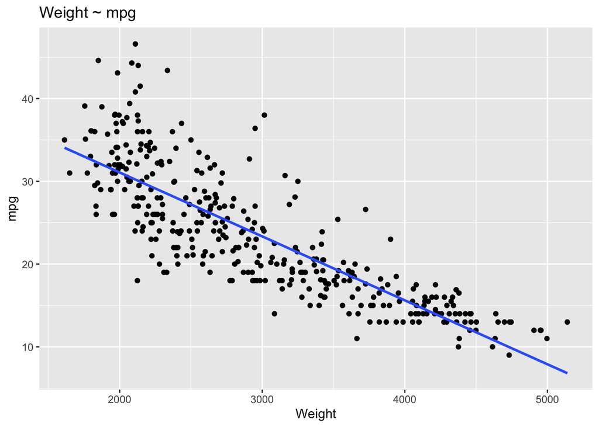

```r
ggplot(auto, mapping = aes(x = weight, y = mpg)) +
  geom_point() +
  labs(x = "Weight", y = "mpg", title = "Weight ~ mpg") +
  geom_smooth(method = "lm", se = FALSE)
```

The analysis suggests that there is a correlation between more cylinders and a smaller mile per gallon and a higher weight and a smaller mile per gallon.

### 3a Loading the Boston dataset

The dataset contains 485 rows and 14 columns. The rows represent a single record in the datset whereas the columns represent the variables of the datset.

```r
boston <- read.csv("/Users/admin/Downloads/boston.csv")
glimpse(boston)
```

```
## Rows: 485
## Columns: 14
## $ X       <int> 1, 2, 3, 4, 5, 6, 7, 8, 9, 10, 11, 12, 13, 14, 15, 16, 17, 18,…
## $ crim    <dbl> 0.00632, 0.02731, 0.02729, 0.03237, 0.06905, 0.02985, 0.08829,…
## $ zn      <dbl> 18.0, 0.0, 0.0, 0.0, 0.0, 0.0, 12.5, 12.5, 12.5, 12.5, 12.5, 1…
## $ indus   <dbl> 2.31, 7.07, 7.07, 2.18, 2.18, 2.18, 7.87, 7.87, 7.87, 7.87, 7.…
## $ chas    <int> 0, 0, 0, 0, 0, 0, 0, 0, 0, 0, 0, 0, 0, 0, 0, 0, 0, 0, 0, 0, 0,…
## $ nox     <dbl> 0.538, 0.469, 0.469, 0.458, 0.458, 0.458, 0.524, 0.524, 0.524,…
## $ rm      <dbl> 6.575, 6.421, 7.185, 6.998, 7.147, 6.430, 6.012, 6.172, 5.631,…
## $ age     <dbl> 65.2, 78.9, 61.1, 45.8, 54.2, 58.7, 66.6, 96.1, 100.0, 85.9, 9…
## $ dis     <dbl> 4.0900, 4.9671, 4.9671, 6.0622, 6.0622, 6.0622, 5.5605, 5.9505…
## $ rad     <int> 1, 2, 2, 3, 3, 3, 5, 5, 5, 5, 5, 5, 5, 4, 4, 4, 4, 4, 4, 4, 4,…
## $ tax     <int> 296, 242, 242, 222, 222, 222, 311, 311, 311, 311, 311, 311, 31…
## $ ptratio <dbl> 15.3, 17.8, 17.8, 18.7, 18.7, 18.7, 15.2, 15.2, 15.2, 15.2, 15…
## $ lstat   <dbl> 4.98, 9.14, 4.03, 2.94, 5.33, 5.21, 12.43, 19.15, 29.93, 17.10…
## $ medv    <dbl> 24.0, 21.6, 34.7, 33.4, 36.2, 28.7, 22.9, 27.1, 16.5, 18.9, 15…
```

### 3b. Pairwise scatterpolots of the predictor columns

```r
str(boston)
```

```
## 'data.frame':    485 obs. of  14 variables:
##  $ X      : int  1 2 3 4 5 6 7 8 9 10 ...
##  $ crim   : num  0.00632 0.02731 0.02729 0.03237 0.06905 ...
##  $ zn     : num  18 0 0 0 0 0 12.5 12.5 12.5 12.5 ...
##  $ indus  : num  2.31 7.07 7.07 2.18 2.18 2.18 7.87 7.87 7.87 7.87 ...
##  $ chas   : int  0 0 0 0 0 0 0 0 0 0 ...
##  $ nox    : num  0.538 0.469 0.469 0.458 0.458 0.458 0.524 0.524 0.524 0.524 ...
##  $ rm     : num  6.58 6.42 7.18 7 7.15 ...
##  $ age    : num  65.2 78.9 61.1 45.8 54.2 58.7 66.6 96.1 100 85.9 ...
##  $ dis    : num  4.09 4.97 4.97 6.06 6.06 ...
##  $ rad    : int  1 2 2 3 3 3 5 5 5 5 ...
##  $ tax    : int  296 242 242 222 222 222 311 311 311 311 ...
##  $ ptratio: num  15.3 17.8 17.8 18.7 18.7 18.7 15.2 15.2 15.2 15.2 ...
##  $ lstat  : num  4.98 9.14 4.03 2.94 5.33 ...
##  $ medv   : num  24 21.6 34.7 33.4 36.2 28.7 22.9 27.1 16.5 18.9 ...
```

Converting ints to numeric values

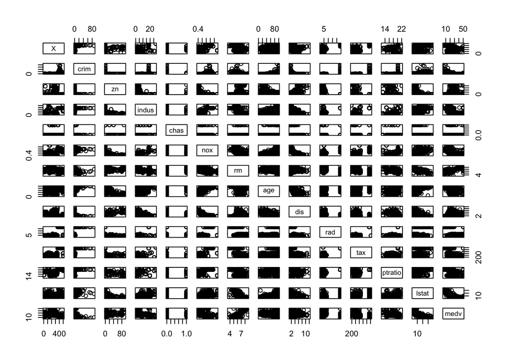

```r
boston$chas <- as.numeric(boston$chas)
boston$rad <- as.numeric(boston$rad)
boston$tax <- as.numeric(boston$tax)
pairs(boston)
```

The findings indicate that there are some strong and weak correlations between some of the variables.

### 3c. Associations with per capita crime rate

```r
correlations <- cor(boston)
correlations_with_crim <- correlations[, "crim"]
correlations_with_crim
```

```
##           X        crim          zn       indus        chas         nox
##  0.40088083  1.00000000 -0.19384321  0.39956287 -0.06105289  0.41409408
##          rm         age         dis         rad         tax     ptratio
## -0.22521094  0.34903165 -0.37594209  0.62284159  0.58005637  0.29166966
##       lstat        medv
##  0.45870243 -0.39228714
```

Some positive correlation between crime rate and taxes with a 0.5800564 correlation.

```r
cor(boston$crim, boston$tax)
```

```
## [1] 0.5800564
```

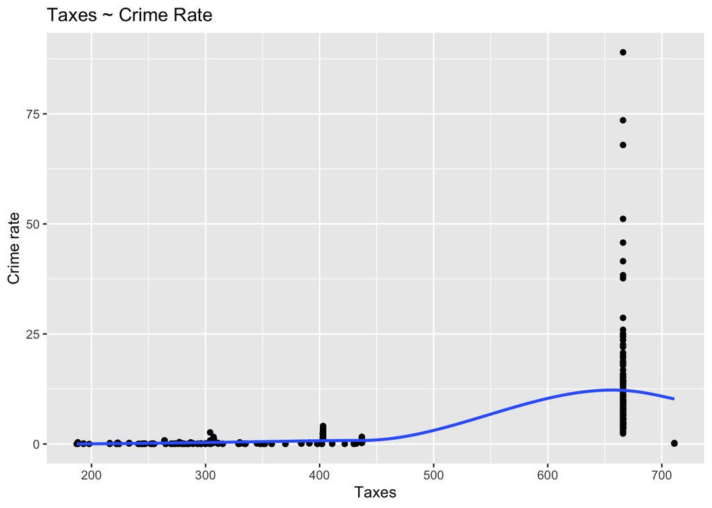

```r
ggplot(boston, mapping=aes(x= tax, y = crim)) +
  geom_point()+
  labs(x = "Taxes", y = "Crime rate", title = "Taxes ~ Crime Rate") +
  geom_smooth(model = "lm", se = FALSE)
```

Some positive correlation between crime rate and accessibility to radial highways with a 0.6228416 correlation.

```r
cor(boston$crim, boston$rad)
```

```
## [1] 0.6228416
```

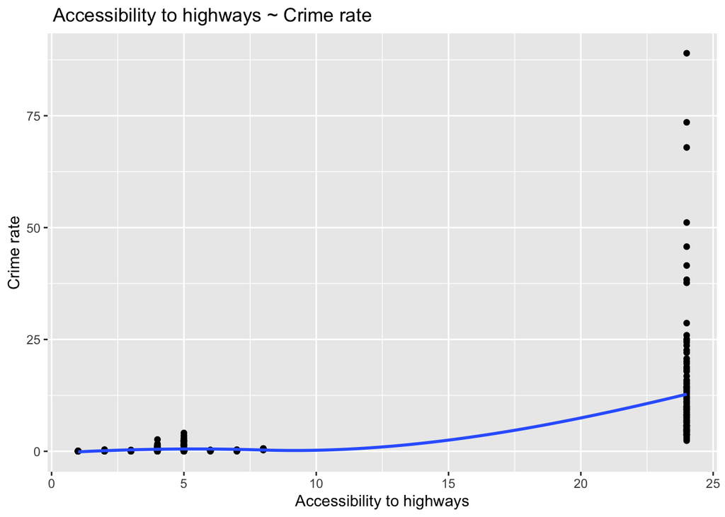

```r
ggplot(boston, mapping=aes(x= rad, y = crim)) +
  geom_point()+
  labs(x = "Accessibility to highways", y = "Crime rate", title = " Accessibility to highways ~ Crime rate") +
  geom_smooth(model = "lm", se = FALSE)
```

Very weak negative correlation between crime rate and average number of rooms with a -0.2252109 correlation.

```r
cor(boston$crim, boston$rm)
```

```
## [1] -0.2252109
```

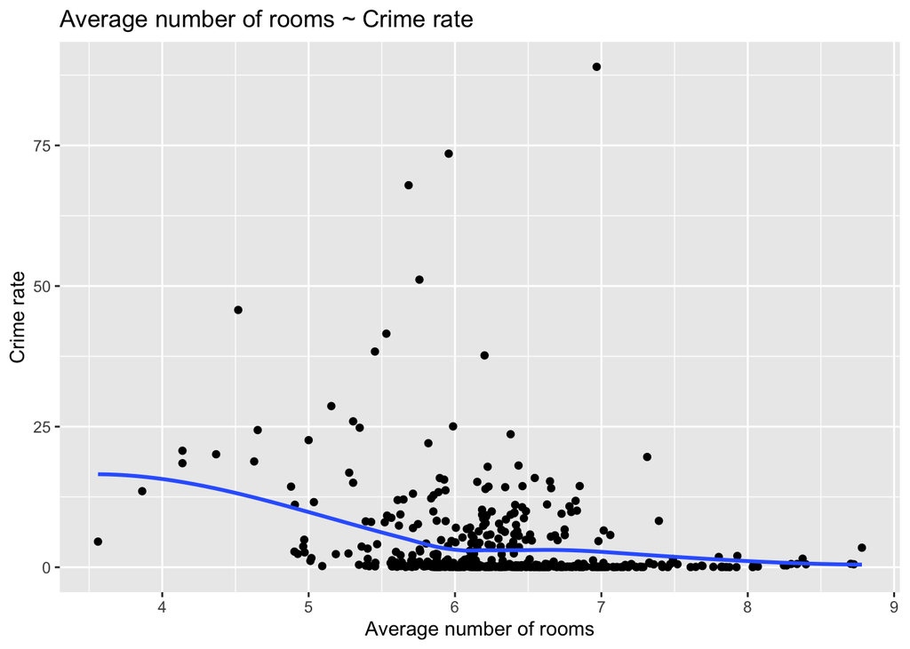

```r
ggplot(boston, mapping=aes(x= rm, y = crim)) +
  geom_point()+
  labs(x = "Average number of rooms", y = "Crime rate", title = "Average number of rooms ~ Crime rate") +
  geom_smooth(model = "lm", se = FALSE)
```

### 3d. Crime rates and tax rates of Boston suburbs

```r
summary(boston$crim)
```

```
##     Min.  1st Qu.   Median     Mean  3rd Qu.     Max.
##  0.00632  0.08387  0.29819  3.76611  3.84970 88.97620
```

The average crime rate is 3.76, but some suburbs have much higher crime rates as evident by the maximum crime rate of 88.97620.

```r
summary(boston$tax)
```

```
##    Min. 1st Qu.  Median    Mean 3rd Qu.    Max.
##   187.0   281.0   335.0   413.6   666.0   711.0
```

The tax rates vary greatly, with a minimum tax rate of $187 per $10,000 but some suburbs have up to $711 per $10,000.

```r
summary(boston$ptratio)
```

```
##    Min. 1st Qu.  Median    Mean 3rd Qu.    Max.
##   12.60   17.40   19.10   18.47   20.20   22.00
```

The pupil teacher ratios have some variation with a minimum of 12.60 pupils to teachers up to 22 pupils per teachers in some suburbs.

### 3e. There are 35 suburbs in Boston that bound the Charles River.

```r
boston %>%
  filter(chas == 1) %>%
  summarize(count = n())
```

```
##   count
## 1    35
```

### 3f. The median pupil-teacher ratio among the towns in the dataset is 19.1.

```r
median(boston$ptratio)
```

```
## [1] 19.1
```

### 3g. The lowest value of median owner occupied homes is $5,000 and it belongs to the suburbs 399 and 406.

```r
summary(boston$medv)
```

```
##    Min. 1st Qu.  Median    Mean 3rd Qu.    Max.
##    5.00   16.70   21.20   22.53   25.00   50.00
```

```r
boston %>%
  group_by(X) %>%
  filter(medv == 5)
```

```
## # A tibble: 2 × 14
## # Groups:   X [2]
##       X  crim    zn indus  chas   nox    rm   age   dis   rad   tax ptratio
##   <int> <dbl> <dbl> <dbl> <dbl> <dbl> <dbl> <dbl> <dbl> <dbl> <dbl>   <dbl>
## 1   399  38.4     0  18.1     0 0.693  5.45   100  1.49    24   666    20.2
## 2   406  67.9     0  18.1     0 0.693  5.68   100  1.43    24   666    20.2
## # ℹ 2 more variables: lstat <dbl>, medv <dbl>
```

```r
boston %>%
  filter(X == 399 | X == 406)
```

```
##     X    crim zn indus chas   nox    rm age    dis rad tax ptratio lstat medv
## 1 399 38.3518  0  18.1    0 0.693 5.453 100 1.4896  24 666    20.2 30.59    5
## 2 406 67.9208  0  18.1    0 0.693 5.683 100 1.4254  24 666    20.2 22.98    5
```

```r
summary(boston)
```

```
##        X              crim                zn            indus
##  Min.   :  1.0   Min.   : 0.00632   Min.   : 0.00   Min.   : 0.46
##  1st Qu.:143.0   1st Qu.: 0.08387   1st Qu.: 0.00   1st Qu.: 5.32
##  Median :264.0   Median : 0.29819   Median : 0.00   Median : 9.90
##  Mean   :261.9   Mean   : 3.76611   Mean   :10.23   Mean   :11.42
##  3rd Qu.:385.0   3rd Qu.: 3.84970   3rd Qu.: 0.00   3rd Qu.:18.10
##  Max.   :506.0   Max.   :88.97620   Max.   :95.00   Max.   :27.74
##       chas              nox               rm             age
##  Min.   :0.00000   Min.   :0.3850   Min.   :3.561   Min.   :  2.90
##  1st Qu.:0.00000   1st Qu.:0.4640   1st Qu.:5.887   1st Qu.: 46.30
##  Median :0.00000   Median :0.5380   Median :6.211   Median : 79.20
##  Mean   :0.07216   Mean   :0.5601   Mean   :6.290   Mean   : 69.55
##  3rd Qu.:0.00000   3rd Qu.:0.6310   3rd Qu.:6.629   3rd Qu.: 94.30
##  Max.   :1.00000   Max.   :0.8710   Max.   :8.780   Max.   :100.00
##       dis              rad              tax           ptratio
##  Min.   : 1.130   Min.   : 1.000   Min.   :187.0   Min.   :12.60
##  1st Qu.: 2.065   1st Qu.: 4.000   1st Qu.:281.0   1st Qu.:17.40
##  Median : 3.067   Median : 5.000   Median :335.0   Median :19.10
##  Mean   : 3.646   Mean   : 9.748   Mean   :413.6   Mean   :18.47
##  3rd Qu.: 4.779   3rd Qu.:24.000   3rd Qu.:666.0   3rd Qu.:20.20
##  Max.   :12.127   Max.   :24.000   Max.   :711.0   Max.   :22.00
##      lstat            medv
##  Min.   : 1.73   Min.   : 5.00
##  1st Qu.: 7.12   1st Qu.:16.70
##  Median :11.48   Median :21.20
##  Mean   :12.75   Mean   :22.53
##  3rd Qu.:17.12   3rd Qu.:25.00
##  Max.   :37.97   Max.   :50.00
```

The suburbs that average more than 8 rooms have an average crime rate of 0.71879, a range of taxes from $224 - $666 per $10,000 and an average distance of 3.430 to five Boston employment centers.

```r
boston %>%
  filter(rm > 7) %>%
  summarize(count = n())
```

```
##   count
## 1    62
```

```r
boston %>%
  filter(rm > 8) %>%
  summarize(count = n())
```

```
##   count
## 1    13
```

```r
eight_rooms <- boston %>%
  filter(rm > 8)

summary(eight_rooms)
```

```
##        X              crim               zn            indus
##  Min.   : 98.0   Min.   :0.02009   Min.   : 0.00   Min.   : 2.680
##  1st Qu.:225.0   1st Qu.:0.33147   1st Qu.: 0.00   1st Qu.: 3.970
##  Median :233.0   Median :0.52014   Median : 0.00   Median : 6.200
##  Mean   :232.3   Mean   :0.71879   Mean   :13.62   Mean   : 7.078
##  3rd Qu.:258.0   3rd Qu.:0.57834   3rd Qu.:20.00   3rd Qu.: 6.200
##  Max.   :365.0   Max.   :3.47428   Max.   :95.00   Max.   :19.580
##       chas             nox               rm             age
##  Min.   :0.0000   Min.   :0.4161   Min.   :8.034   Min.   : 8.40
##  1st Qu.:0.0000   1st Qu.:0.5040   1st Qu.:8.247   1st Qu.:70.40
##  Median :0.0000   Median :0.5070   Median :8.297   Median :78.30
##  Mean   :0.1538   Mean   :0.5392   Mean   :8.349   Mean   :71.54
##  3rd Qu.:0.0000   3rd Qu.:0.6050   3rd Qu.:8.398   3rd Qu.:86.50
##  Max.   :1.0000   Max.   :0.7180   Max.   :8.780   Max.   :93.90
##       dis             rad              tax           ptratio
##  Min.   :1.801   Min.   : 2.000   Min.   :224.0   Min.   :13.00
##  1st Qu.:2.288   1st Qu.: 5.000   1st Qu.:264.0   1st Qu.:14.70
##  Median :2.894   Median : 7.000   Median :307.0   Median :17.40
##  Mean   :3.430   Mean   : 7.462   Mean   :325.1   Mean   :16.36
##  3rd Qu.:3.652   3rd Qu.: 8.000   3rd Qu.:307.0   3rd Qu.:17.40
##  Max.   :8.907   Max.   :24.000   Max.   :666.0   Max.   :20.20
##      lstat           medv
##  Min.   :2.47   Min.   :21.9
##  1st Qu.:3.32   1st Qu.:41.7
##  Median :4.14   Median :48.3
##  Mean   :4.31   Mean   :44.2
##  3rd Qu.:5.12   3rd Qu.:50.0
##  Max.   :7.44   Max.   :50.0
```